# Bellabeat Case Study

McKenna Bell Duffy

2023-07-07

### Introduction

This case study is part of my capstone project for the Google Data Analytics Professional Certificate Program.

The client in this case study is Bellabeat, a high-tech manufacturer of health-focused products for women. Bellabeat is a successful company, cofounded by Urška Sršen and Sando Mur.

The products innovated by Bellabeat include:

- **Bellabeat App**: The app provides users with health data related to their activity, sleep, stress, menstrual cycle, and mindfulness habits. This data can help users better understand their current habits and make healthy decisions. The Bellabeat app connects to their line of smart wellness products; the Leaf, Time, and Spring:
- **Leaf**: Bellabeat’s classic wellness tracker can be worn as a bracelet, necklace, or clip. The Leaf tracker connects to the Bellabeat app to track activity, sleep, and stress.
- **Time**: This wellness watch combines the timeless look of a classic timepiece with smart technology to track user activity, sleep, and stress. The Time watch connects to the Bellabeat app to provide you with insights into your daily wellness.
- **Spring**: This is a water bottle that tracks daily water intake using smart technology to ensure that you are appropriately hydrated throughout the day. The Spring bottle connects to the Bellabeat app to track your hydration levels.

In addition to the integrated wellness products they created, they also provide their users with a community:

- **Bellabeat Membership**: Bellabeat also offers a subscription-based membership program for users. Membership gives users 24/7 access to fully personalized guidance on nutrition, activity, sleep, health and beauty, and mindfulness based on their lifestyle and goals.

### Ask: The Business Task

As Chief Creative Officer of Bellabeat, Urška Sršen has provided our marketing analytics team with the opportunity to **analyze** smart device usage data, **identify** usage trends, and **explore** how these trends could be applied to the Bellabeat customer community so as to **inform** the company’s marketing strategy.

Her request included the following guiding questions:

- What are some trends in device usage?
- How could these trends apply to Bellabeat customers?
- How could these trends help influence Bellabeat marketing strategy?

At the end, I will apply insights to the wearable **Time** and **Leaf** devices, discuss my conclusions, and lay out proposed next steps.

### Prepare Data

For this study, I was directed to the FitBit Fitness Tracker Data dataset (CC0: Public Domain, dataset made available through Mobius): In this Kaggle dataset, thirty-three eligible Fitbit users consented to the submission of personal tracker data, including minute-level output for physical activity, heart rate, and sleep monitoring. It includes information about daily activity, steps, and heart rate that can be used to explore users’ habits.

I acknowledge that internal data from Bellabeat’s own customers would be ideal for this study, but I will be using the FitBit dataset as proxy until Bellabeat internal data becomes available.

ROCC Test:

**Reliable**: This dataset includes a sample of 33, which is a relatively small sample, and therefore may have sampling bias. For example, given that Bellabeat customers are predominantly women, it would be preferable to sample female FitBit users to match population demographics. Additionally, the dataset only includes users of FitBit Fitness Trackers, and excludes users of other fitness trackers, and therefore may not fully represent the target population.

**Original**: This dataset is provided by the original data source, generated by respondents to a distributed survey via Amazon Mechanical Turk.

**Comprehensive**: This dataset is somewhat comprehensive; it has a small sample size (33) with some incomplete data. Data was collected over a one month period, during which time the trackers were not always worn by users. Therefore, I recommend further analysis with a larger, more complete dataset in the future.

**Current**: The dataset is not current. The data was collected between April 2016 and May 2016, and we would recommend further analysis with a dataset taken directly from current Bellabeat customers to maximize accuracy.

### Process Data

#### Step 1: Install and load packages

This allows me to clean, organize, and visualize my data

```r
install.packages("tidyverse")
install.packages("janitor")
install.packages("dplyr")
library(tidyverse)
library(janitor)
library(dplyr)
```

#### Step 2: Upload datasets

There were 18 datasets included, and upon first glance, I noticed that of the 18 total datasets:

- 3 datasets were exact duplicates (long & wide versions of the same data)
- 3 datasets were subsets of a fourth dataset (Calories, Steps, and Intensities were all included in Activity)
- 5 datasets recorded data by the minute (hourly & daily data was used for this analysis)
- 1 dataset only had consistent data on 2 out of 33 users and was therefore unusable (Weight Log)
- 1 dataset recorded heart rate by the second (hourly & daily data was used for this analysis)

therefore I uploaded 5 datasets:

- daily activity
- daily sleep
- hourly calories
- hourly intensities
- hourly steps

```r
daily_activity <- read_csv("dailyActivity_merged.csv")
daily_sleep <- read_csv("sleepDay_merged.csv")
hourly_calories <- read_csv("hourlyCalories_merged.csv")
hourly_intensities <- read_csv("hourlyIntensities_merged.csv")
hourly_steps <- read_csv("hourlySteps_merged.csv")
```

#### Step 3: Clean data

During the data **cleaning** process, I performed the following:

- renamed columns to make them more readable
- assimilated column names if shared between two or more datasets
- adjusted date/time formats to date only formats by separating date and time
- adjusted time formats to 24-hour time format
- excluded data with null values
- removed duplicate entries

```r
daily_activity <- clean_names(daily_activity) %>%
  drop_na() %>%
  distinct()
daily_sleep <- clean_names(daily_sleep) %>%
  drop_na() %>%
  distinct()
hourly_calories <- clean_names(hourly_calories) %>%
  drop_na() %>%
  distinct()
hourly_intensities <- clean_names(hourly_intensities) %>%
  drop_na() %>%
  distinct()
hourly_steps <- clean_names(hourly_steps) %>%
  drop_na() %>%
  distinct()

daily_sleep <- rename(daily_sleep, activity_date = sleep_day)

daily_sleep$activity_date = as.Date(daily_sleep$activity_date,
                                  format="%m/%d/%Y", tz=Sys.timezone())
daily_activity$activity_date = as.Date(daily_activity$activity_date,
                                    format="%m/%d/%Y", tz=Sys.timezone())

daily_activity$day_of_week <- weekdays(as.Date(daily_activity$activity_date))
daily_activity$day_of_week <- factor(daily_activity$day_of_week, levels = c("Sunday", "Monday", "Tuesday", "Wednesday", "Thursday", "Friday", "Saturday"))
```

#### Step 4: Organize data

During the data **organization** process, I performed the following:

- merged the daily activity & daily sleep -> daily totals
- merged the hourly calories, hourly steps, and hourly intensities -> hourly totals
- created a new dataset for averages of daily totals for easier visualization
- filtered out incomplete data

```r
hourly_totals <- merge(hourly_calories, hourly_intensities, by = c("id", "activity_hour"))
hourly_totals <- merge(hourly_totals, hourly_steps,by = c("id", "activity_hour"))

daily_totals <- merge(daily_activity, daily_sleep, by=c("id", "activity_date"), all = "TRUE") %>%
  drop_na()

daily_averages <- daily_totals %>%
  group_by(id) %>%
  select(total_steps, calories, total_minutes_asleep, very_active_minutes, fairly_active_minutes, lightly_active_minutes, sedentary_minutes) %>%
  summarize(avg_steps = mean(total_steps), avg_cals = mean(calories), avg_sleep = mean(total_minutes_asleep)/60, avg_sed_mins = mean(sedentary_minutes), avg_very_active = mean(very_active_minutes), avg_fairly_active = mean(fairly_active_minutes), avg_lightly_active = mean(lightly_active_minutes))
```

### Analyze and Share Data Story

After data is cleaned and organized, it’s ready for analysis and exploration. This will be broken down into three sections:

1. Sleep
2. Weekly Activity
3. Daily Activity

I’ll discuss each of the three components, then discuss the implications and propose actionable steps for Bellabeat’s marketing strategy at the end. Let’s begin with sleep:

#### Sleep:

Let’s see how much sleep the participants are getting on average:

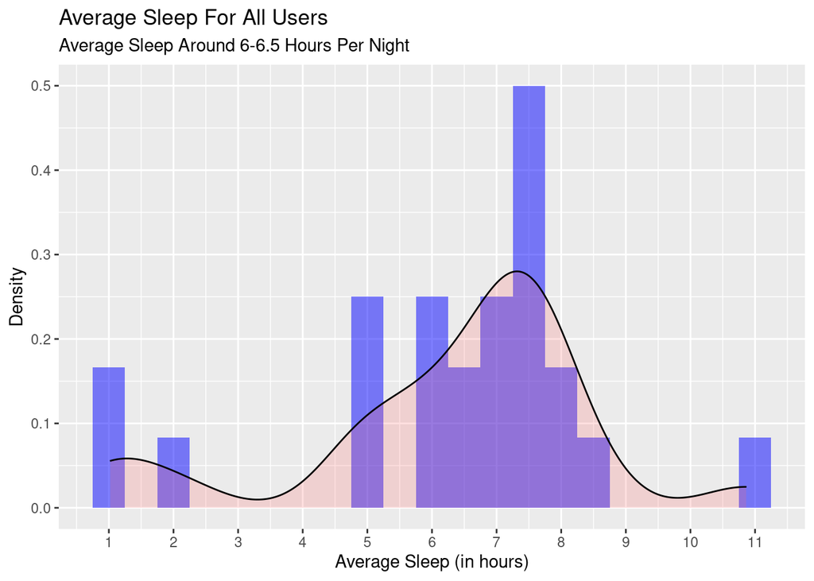

```r
ggplot(data = daily_averages, aes(x=avg_sleep)) +
  geom_histogram(aes(y=after_stat(density)), binwidth=0.5, fill='blue', alpha=0.5) +
  geom_density(alpha=.2, fill="#FF6666") +
  labs(title="Average Sleep For All Users", subtitle = "Average Sleep Around 6-6.5 Hours Per Night", x = "Average Sleep (in hours)", y = "Density") +
  scale_x_continuous(breaks = 1:12)
```

Visualization: This graph shows that three users recorded an average of 1 - 2 hours of sleep per night. For the purpose of this study I will treat these records as an error due to removal of the device at or around bed time. Therefore, to understand user’s sleep habits, it may be more helpful to see a graph with these potential errors removed.

```r
clean_sleep <- daily_sleep %>%
  filter(total_minutes_asleep > "181" & total_minutes_asleep < "657") %>%
  filter(total_minutes_asleep != "58") %>%
  filter(total_minutes_asleep !=  "59") %>%
  filter(total_minutes_asleep != "61") %>%
  filter(total_minutes_asleep != "62")

daily_totals_clean <- merge(daily_activity, clean_sleep, by=c("id", "activity_date"), all = "TRUE") %>%
  drop_na()

daily_averages_clean <- daily_totals_clean %>%
  group_by(id) %>%
  select(total_steps, calories, sedentary_minutes, total_minutes_asleep) %>%
  filter(total_minutes_asleep > "180") %>%
  summarize(avg_steps = mean(total_steps), avg_cals = mean(calories), avg_sed_mins = mean(sedentary_minutes), avg_sleep = mean(total_minutes_asleep)/60)
```

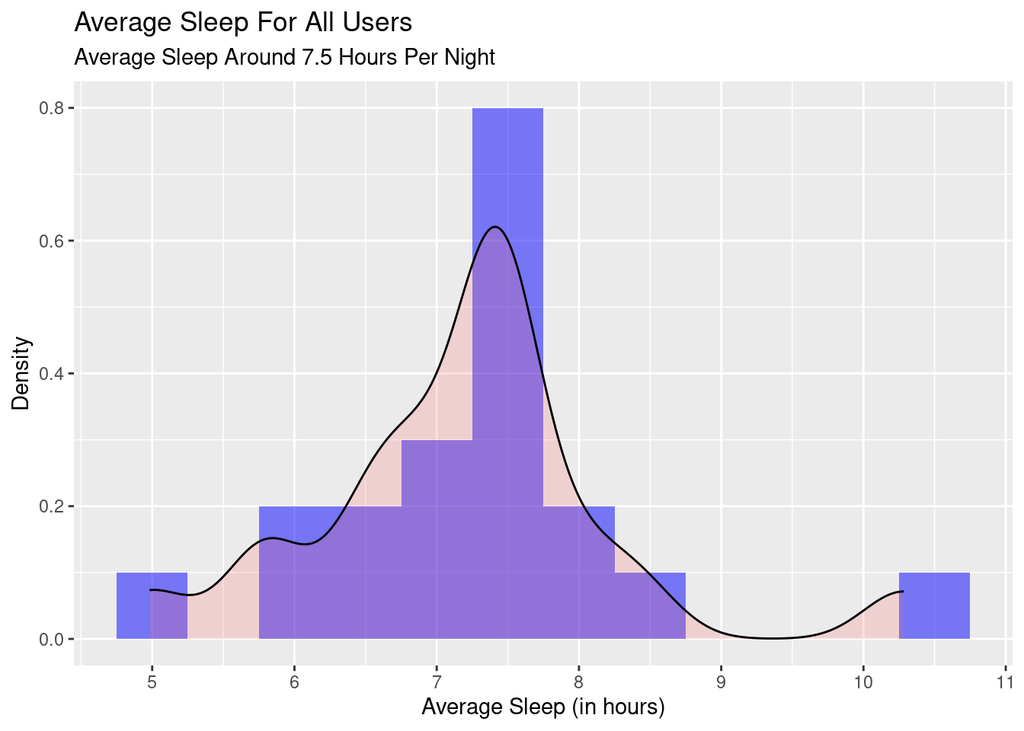

```r
ggplot(data = daily_averages_clean, aes(x=avg_sleep)) +
  geom_histogram(aes(y=after_stat(density)), binwidth=0.5, fill='blue', alpha=0.5) +
  geom_density(alpha=.2, fill="#FF6666") +
  labs(title="Average Sleep For All Users", subtitle = "Average Sleep Around 7.5 Hours Per Night", x = "Average Sleep (in hours)", y = "Density") +
  scale_x_continuous(breaks = 1:12)
```

Visualization: This graph shows that the average amount of sleep is 7.5 hours per night.

Takeaways: The average amount of sleep recorded shows that many of the users may not be getting the recommended * 7 - 9 hours of sleep each night. I would also note that of the 33 total participants, 24 recorded sleep, and only 3 of the 24 recorded their sleep every night, which means that these data may not be painting a complete picture.

*1. National Sleep Foundation. (2015). National Sleep Foundation recommends new sleep times. Retrieved from: https://www.sleepfoundation.org/press-release/national-sleep-foundation-recommends-new-sleep-times

*2. Watson, N. F., Badr, M. S., Belenky, G., Bliwise, D. L., Buxton, O. M., Buysse, D., … & Tasali, E. (2015). Recommended Amount of Sleep for a Healthy Adult: A Joint Consensus Statement of the American Academy of Sleep Medicine and Sleep Research Society. Journal of Clinical Sleep Medicine, 11(06), 591-592. Retrieved from: https://jcsm.aasm.org/doi/10.5664/jcsm.4758

Now that we’ve looked at users’ sleep habits, let’s take a look at their activity levels through the week:

#### Weekly Activity:

Here, I’ve used each user’s average steps throughout the week as one representation of activity.

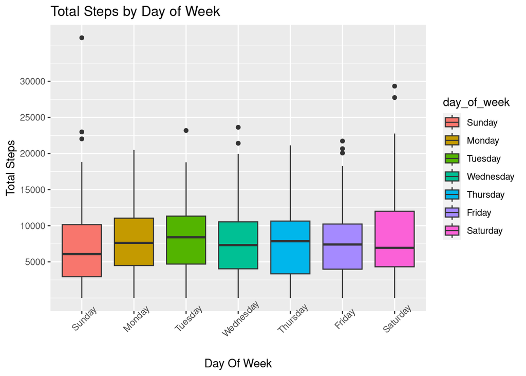

```r
daily_activity$day_of_week <- weekdays(as.Date(daily_activity$activity_date, format="%m/%d/%Y"))
daily_activity$day_of_week <- factor(daily_activity$day_of_week, levels = c("Sunday", "Monday", "Tuesday", "Wednesday", "Thursday", "Friday", "Saturday"))

ggplot(daily_activity) +
  geom_boxplot(mapping = aes( x = day_of_week, y= total_steps, fill = day_of_week)) +
  labs(title= "Total Steps by Day of Week", x= "Day Of Week", y= "Total Steps") +
  theme(axis.text.x = element_text(angle = 45)) +
  scale_y_continuous(breaks = seq(5000, 30000, by = 5000))
```

```r
daily_activity %>%
  group_by(day_of_week) %>%
  summarize(mean(total_steps))
```

```
## # A tibble: 7 × 2
##   day_of_week `mean(total_steps)`
##   <fct>                     <dbl>
## 1 Sunday                    6933.
## 2 Monday                    7781.
## 3 Tuesday                   8125.
## 4 Wednesday                 7559.
## 5 Thursday                  7406.
## 6 Friday                    7448.
## 7 Saturday                  8153.
```

Visualization: This graph (and accompanying table) illustrates that Saturday and Tuesday are users’ most active days, and Sundays are their least active days. It is worth noting that the total spread of mean steps per day is only about 1200 steps, which indicates that the distribution is relatively uniform.

Now that we’ve seen our participants’ average daily step count, let’s explore their various activity intensities each day.

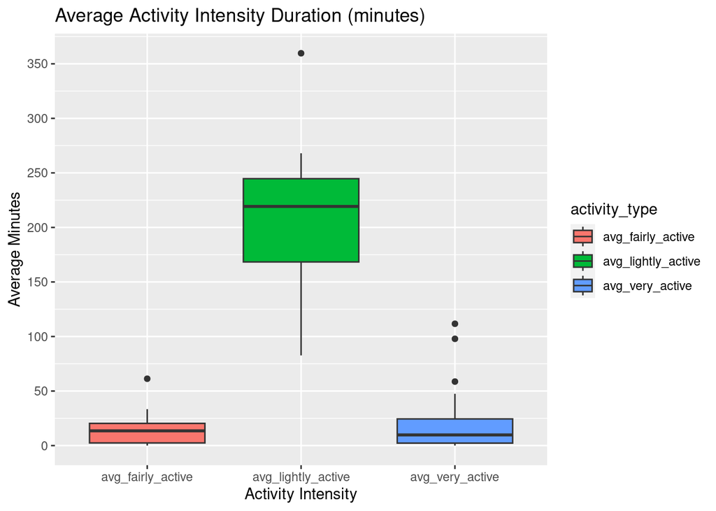

```r
daily_averages_long <- daily_averages %>%
  select(avg_very_active, avg_fairly_active, avg_lightly_active) %>%
  pivot_longer(
    cols = starts_with("avg"),
    names_to = "activity_type",
    values_to = "average_minutes")

ggplot(data = daily_averages_long, aes(x = activity_type, y = average_minutes, fill = activity_type)) +
  geom_boxplot() +
  labs(title = "Average Activity Intensity Duration (minutes)", x = "Activity Intensity", y = "Average Minutes") +
  scale_y_continuous(breaks = seq(0, 400, by = 50))
```

Takeaways: We should note that while the amount of light activity meets or exceeds health standards,* the amount of participation in fairly active to very active exercise does fall below the recommended * amount.

Given that 32 out of 33 users were consistently using their devices to record activity during the day, it appears that these consumers are utilizing this feature to its full capacity. This indicates that Bellabeat consumers may also utilize exercise/activity tracking features. While tracking average intensity each day is helpful to see broad trends, we can also take a look at what time of day users’ activity intensity is highest, indicating they may tend to exercise at specific times of the day.

*3. U.S. Department of Health and Human Services. (2018). Physical Activity Guidelines for Americans, 2nd edition. [Online]. Available at: https://health.gov/sites/default/files/2019-09/Physical_Activity_Guidelines_2nd_edition.pdf [Accessed 10 July 2023].

#### Daily Activity:

In this next graphic, I examined which times of the day are most often used for higher intensity activities.

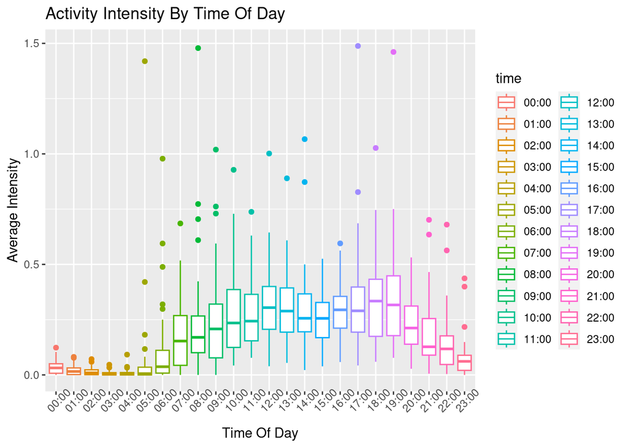

```r
hourly_intensities$activity_hour=as.POSIXct(hourly_intensities$activity_hour, format="%m/%d/%Y %I:%M:%S %p", tz=Sys.timezone())
hourly_intensities$time <- format(hourly_intensities$activity_hour, format = "%H:%M")
hourly_intensities$date <- format(hourly_intensities$activity_hour, format = "%m/%d/%y")

hourly_intensities_avg <- hourly_intensities %>%
  group_by(id, time) %>%
  summarize(avg_intensity = mean(average_intensity))

ggplot(data = hourly_intensities_avg, aes(x=time, y=avg_intensity)) +
  geom_boxplot(aes(color = time)) +
  theme(axis.text.x = element_text(angle = 45)) +
  labs(title = "Activity Intensity By Time Of Day", x = "Time Of Day", y= "Average Intensity")
```

Visualization: Between 11pm and 5am, there is very little activity among participants who are hopefully resting well! From there, we notice two distinct arcs of activity: Between 6am and 12pm, activity intensity increases, then dips down from 12pm to 3pm. From here, activity increases again from 3pm to 7pm, and then dwindles down as the evening progresses.

Another detail to note is that there is a cluster of data points well above the mean between 5am-8am, and a small set of outliers at 5pm and 7pm.

Takeaways: There is a low point of activity intensity around 3pm, and a cluster of higher intensity activity between 5am and 8am, perhaps showing that users are choosing to exercise or go to the gym before work

### Act: Conclusions and Proposed Next Steps

As I have explored participants’ sleep habits, activity through the week, and activity through the day, I’ve identified trends that can be applied to Bellabeat’s wearable devices, Time and Leaf. In this section, I’ll use these insights to propose next steps in Bellabeat’s marketing strategy, and wrap up with a discussion of what data I *didn’t* find, and how that might affect Bellabeat’s consumer base.

**Sleep:** Only 3 of the 33 users recorded their sleep every night during the study, which means they are likely removing their wearable devices at or around bedtime.

Marketing Tactic: To ensure their customers will fully benefit from the sleep tracking software they provide, I recommend that Bellabeat advertise the comfort-centric nature of their Leaf and Time wearable devices.It may also be helpful to incorporate a customizeable bedtime-reminder into the sleep tracking features.

**Activity:** Beginning with activity intensity, I did note that while participants seem to be getting adequate light activity through the day, amounts of fairly intense and very intense activity could be improved upon.

Marketing Tactic: To promote the personal coaching for yoga, strength training, and cardio workouts that Bellabeat offers, I recommend they advertise these options to existing customers in targeted campaigns focused on clients who are not participating in moderately- to highly- intense activity. Furthermore, to bring in new clientele, they might show how their activity tracking and coaching features had positive impact on existing customers’ physical fitness and include customer testimonies in future campaigns. Lastly, adding customizeable reminders in the mid-afternoon could remind Bellabeat customers to take a walk or spend a few minutes stretching during time periods when physical activity is particularly low.

**What’s Missing? A Personal Comment:** Throughout my exploration of the FitBit datasets, one detail in particular caught my attention and I believe it warrants comment. Within the FitBit data, there was one dataset containing weight log data that contained information from only 8 participants. 6 recorded their weight once or twice, and only 2 out of 33 kept consistent weight records. Whether these participants used other record keeping strategies or chose not to record their weight in any capacity, this nearly complete lack of useable data indicated that I may have needed to pull in additional datasets to accommodate. I went to the Bellabeat website * to determine if weight tracking was a significant part of their featured software, so I could determine the relevance of weight tracking to be considered during this study. However, I found hardly any references to weight loss on their site. Rather, the one reference I did find to weight change listed “weight gain or loss” alongside other aspects of their coaching, like menstrual cycle tracking, getting enough rest, building muscle, and managing stress. Bellabeat’s company focus highlights being “women-centric”, encouraging a “holistic approach and body positivity,” and their choice not to prioritize weight tracking or weight loss clearly shows where their priorities lie. For this reason, I chose not to incorporate any additional datasets regarding weight tracking into my case study, as I did not feel it would add value to the analysis.

*4. Bellabeat. (n.d.). About us. Retrieved July 10, 2023, from https://bellabeat.com/about-us/

Special Thanks: I reviewed similar case studies on Kaggle for inspiration and guidance through my process, and got tremendous value from reading their work:

https://www.kaggle.com/code/macarenalacasa/capstone-case-study-bellabeat

https://www.kaggle.com/code/annaalp/bellabeat-case-study